# Thermal Convection Regimes for an Internally Heated Mantle

This is an example of two modes of mantle convection: stagnant lid and isoviscous, both driven by internal heating.

**Relevant reading:**

- *Stagnant Lid Convection on Venus*, Solomatov and Moresi 1996 (http://onlinelibrary.wiley.com/doi/10.1029/95JE03361/full)
- *Geodynamics, Turcotte and Schubert*, 6-21 in 2nd edition
- *Mantle Convection in the Earth and Planets*, Schubert, Turcotte and Olson, Chapter 7

```python
import underworld as uw
import numpy
import glucifer
import matplotlib.pyplot as plt
from IPython import display
import os

rank = uw.rank()
size = uw.nProcs()

uw.matplotlib_inline()
plt.ion()
```

Do we want to read a previous temperature field in? The answer is usually yes

```python
readTemperature = True
```

Do we want to save figures? If set to true, stagnant lid and isoviscous figures are saved seperately in the current directory. Otherwise, you can look at plots in this notebook.

```python
writefigures = False
```

in Underworld, the heat-source term is entered as $H_c = \frac{H}{ c_p}$, where $H$ is the heat-production in $W\ kg^{-1}$ and $c_p$ is the heat capacity in $J\ kg^{-1}\ K^{-1}$.

$H_c$ subsequently has units of $K\ s^{-1}$

The Rayleigh number for internally heated convection can be written as:

$Ra = \frac{\rho_0 g \alpha H_c L^5}{\kappa^2 \eta}$

Temperature can be scaled as: $T' = T \frac{\kappa}{H_c L^2}$

Set the Rayleigh number

```python
Ra = 1e6
```

```python
# Choose Ra by varying alpha and setting other parameters to 1
H = 1.
diffusivity = 1.
rho0 = 1.
eta0 = 1.
alpha = Ra
```

The temperature between the surface and the interior of the convective cell ($\Delta T$), for internally heated convection, is well approximated as $\Delta T = \beta H Ra^{-\frac{1}{4}}$, where $\beta$ is found empirically (6-346, Geodynamics, Turcotte and Schubert 2007). This is used for benchmarking and for comparison.

```python
predTemp = 2.45 * H * Ra**-0.25
if rank == 0:
    print("For Ra = %.2e, the temperature jump is %.2e" %(Ra,predTemp))
```

```
For Ra = 1.00e+06, the temperature jump is 7.75e-02
```

```python
if rank == 0:
    print("dimensional interior temperature: %.2f K" %(predTemp / 1e-6 * 9e-12 / 1200. * (2900e3)**2.))
```

```
dimensional interior temperature: 4886.79 K
```

How does this compare to the expected value of $\sim 1700 K$ for the Earth? This might give you an idea of the Earth's effective $Ra$ (though the thickness of boundary layer is also important) and the degree to which an internally heated, isoviscous convection model approximates the Earth's heat loss.

**We'll decide on the style of convection here**

Setting the entire mantle to be isoviscous (`isoviscous = True`) results in a surface which can be recycled into the mantle interior. This approximates 'mobile lid convection'. Once surface heat loss and internal heat generation are in equilibrium, we would expect the internal temperature to be well approximated by the calculation of $\Delta T$ above.

Setting the mantle viscosity to be exponentially temperature dependent (`isoviscous = False`) results in 'stagnant lid' convection. In this mode, the surface and a thick 'lid' are stationary, while convection occurs below. Heat loss is much less efficient (relatively lower Nusselt number) and so the interior temperature should be relatively higher for the same heat generation.

```python
isoviscous = False
```

*Set key parameters*

```python
elementType = "Q1/dQ0"
resX = 64
resY = 64
mesh = uw.mesh.FeMesh_Cartesian( elementType = (elementType),
                                 elementRes  = (resX, resY),
                                 minCoord    = (0., 0.),
                                 maxCoord    = (1., 1.))

temperatureField    = mesh.add_variable( nodeDofCount=1 )
temperatureDotField = mesh.add_variable( nodeDofCount=1 )

pressureField    = mesh.subMesh.add_variable( nodeDofCount=1 )
velocityField    = mesh.add_variable( nodeDofCount=2 )
HField = mesh.add_variable( nodeDofCount=1 )
HField.data[:] = H
```

```python
IWalls = mesh.specialSets["MinI_VertexSet"] + mesh.specialSets["MaxI_VertexSet"]
JWalls = mesh.specialSets["MinJ_VertexSet"] + mesh.specialSets["MaxJ_VertexSet"]
BottomWall = mesh.specialSets["MinJ_VertexSet"]
TopWall = mesh.specialSets["MaxJ_VertexSet"]
LeftWall = mesh.specialSets["MinI_VertexSet"]
RightWall = mesh.specialSets["MaxI_VertexSet"]

freeslipBC = uw.conditions.DirichletCondition(     variable=velocityField,
                                              indexSetsPerDof=(IWalls,JWalls) )

# Top wall is set to constant temperature, the others are insulating
tempBC = uw.conditions.DirichletCondition(     variable=temperatureField,
                                              indexSetsPerDof=(TopWall) )

# Un-comment if you want to be really sure that the walls are insulating, though this seems to happen by default.
# neumannBC = uw.conditions.NeumannCondition( fn_flux=0., variable=temperatureField, indexSetsPerDof=IWalls+BottomWall)

mSwarm = uw.swarm.Swarm( mesh=mesh)
nParticles = 12
layout = uw.swarm.layouts.GlobalSpaceFillerLayout( swarm=mSwarm, particlesPerCell=nParticles )
mSwarm.populate_using_layout( layout=layout )

tracerSwarm = uw.swarm.Swarm (mesh=mesh)
tracerSwarm.add_particles_with_coordinates(numpy.array([(0.3,0.5)]))
tracerTrackSwarm = uw.swarm.Swarm (mesh=mesh)
```

```python
advDiff = uw.systems.AdvectionDiffusion( temperatureField, temperatureDotField,
        velocityField,
        fn_diffusivity=diffusivity, fn_sourceTerm=HField, conditions=[tempBC])#,neumannBC])

advector = uw.systems.SwarmAdvector( swarm=mSwarm, velocityField=velocityField, order=2 )

traceradvector = uw.systems.SwarmAdvector( swarm=tracerSwarm, velocityField=velocityField, order=2 )
```

```python
if isoviscous:
    mname = "isovisc"
else:
    mname = "stag"


if readTemperature:
    temperatureField.load("input/1_12_Internally_Heated_Convection/temperature_%s.h5" %mname, interpolate=True)


else:
    CoordFn = uw.function.input()
    surfGradFn = 10.*(1. - (1.+0.0*uw.function.math.cos(CoordFn[0]  * 3.14))* CoordFn[1])
    maxTemp = 0.1
    initialFn = uw.function.branching.conditional( [(surfGradFn < 0.,0.),( surfGradFn < maxTemp , surfGradFn),(True,maxTemp)])
    temperatureField.data[:] = initialFn.evaluate(mesh)


refTemp = uw.function.misc.constant(1.)

maxTemp = numpy.max(temperatureField.data[:,0])
refTemp.value = maxTemp
```

```python
mIVar = mSwarm.add_variable( dataType="int", count=1)
mIVar.data[:] = 0



MrhoFn = rho0 * (1. - alpha* ( temperatureField ))

dicDensity = {0:MrhoFn}

densityFn = uw.function.branching.map( fn_key = mIVar,
        mapping = dicDensity)
```

```python
figMaterial = glucifer.Figure( figsize=(800,400), title="Initial Temperature Field" )
figMaterial.append( glucifer.objects.Surface(mesh,temperatureField ))
# figMaterial.show()
```

Set the maxmimum viscosity contrast between material at the maximum and mininum temperatures, which by default is five orders of magnitude.

```python
surfEta = 1e5
```

```python
cEta = numpy.log(surfEta) / refTemp

if isoviscous:
    ArrFunction = 1.
else:
    #Frank-Kamenetskii Temperature-Dependent Rheology
    ArrFunction = uw.function.math.exp(cEta *(refTemp-temperatureField))


dicViscosity = {0:ArrFunction}
viscosityMapFn = uw.function.branching.map( fn_key = mIVar,
        mapping = dicViscosity)
```

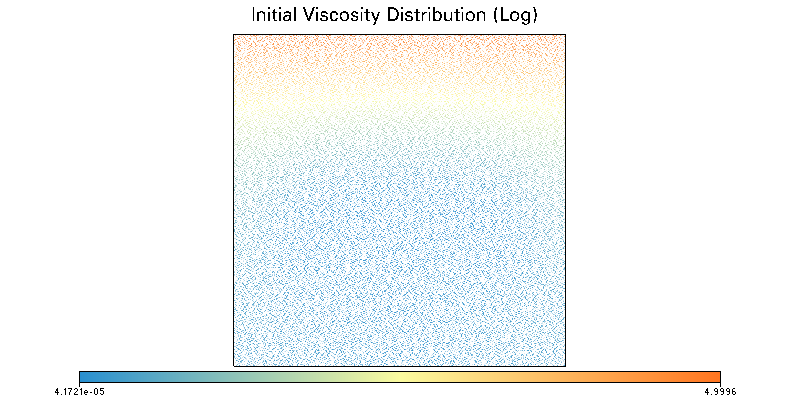

```python
figMaterial = glucifer.Figure( figsize=(800,400), title="Initial Viscosity Distribution (Log)" )
figMaterial.append( glucifer.objects.Points(mSwarm,fn_colour = uw.function.math.log10(viscosityMapFn )))
if size == 1:
    figMaterial.show()
```

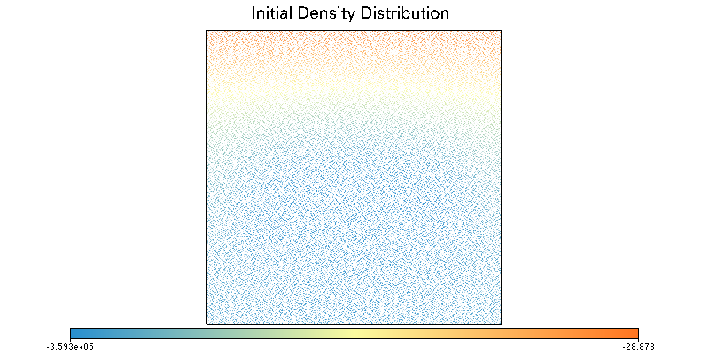

```python
figMaterial = glucifer.Figure( figsize=(800,400), title="Initial Density Distribution" )
figMaterial.append( glucifer.objects.Points(mSwarm,fn_colour = densityFn ))

if size == 1:
    figMaterial.show()
```

```python
stokesPIC = uw.systems.Stokes(velocityField=velocityField,
                              pressureField=pressureField,
                              conditions=[freeslipBC,],
                              fn_viscosity=1.,
                              fn_bodyforce=densityFn*(0.,-1.))


solver=uw.systems.Solver(stokesPIC)
solver.solve()

stokesPIC = uw.systems.Stokes(velocityField=velocityField,
                              pressureField=pressureField,
                              conditions=[freeslipBC,],
                              fn_viscosity=viscosityMapFn,
                              fn_bodyforce=densityFn*(0.,-1.))
solver=uw.systems.Solver(stokesPIC)
```

```python
surfaceHF = uw.utils.Integral( fn = temperatureField.fn_gradient[1], mesh = mesh, integrationType = "surface", surfaceIndexSet = TopWall)
bottomHF = uw.utils.Integral( fn = temperatureField.fn_gradient[1], mesh = mesh, integrationType = "surface", surfaceIndexSet = BottomWall)
leftHF = uw.utils.Integral( fn = temperatureField.fn_gradient[0], mesh = mesh, integrationType = "surface", surfaceIndexSet = LeftWall)
rightHF = uw.utils.Integral( fn = temperatureField.fn_gradient[0], mesh = mesh, integrationType = "surface", surfaceIndexSet = RightWall)
```

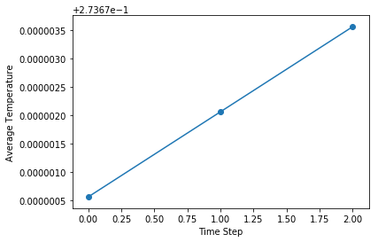

```python
step = 0
maxsteps = 3
yielding = False

if rank == 0:
    arrMeanTemp = numpy.zeros(maxsteps+1)
    arrSurfHF = numpy.zeros(maxsteps+1)
    arrOtherWallsHF = numpy.zeros(maxsteps+1)

for step in range(maxsteps+1):
    solver.solve(nonLinearIterate=yielding)
    cFactor = 0.5
    dt = numpy.min([cFactor * advDiff.get_max_dt(),cFactor * advector.get_max_dt()])
    advDiff.integrate(dt)

    avTemperature = mesh.integrate(temperatureField)[0]
    if rank ==0:
        arrMeanTemp[step] = avTemperature

    traceradvector.integrate(dt)
    tracerTrackSwarm.add_particles_with_coordinates(tracerSwarm.particleCoordinates.data[:])

    surfHF = -1. * surfaceHF.evaluate()[0]
    wallsHF = abs(bottomHF.evaluate()[0])+abs(leftHF.evaluate()[0])+abs(rightHF.evaluate()[0])
    if rank == 0:
        arrSurfHF[step] = surfHF
        arrOtherWallsHF[step] = wallsHF

    refTemp.value = numpy.max(temperatureField.data[:])

if rank == 0:
    plt.plot(range(maxsteps),arrMeanTemp[:step])
    plt.scatter(range(maxsteps),arrMeanTemp[:step])

    plt.xlabel("Time Step")
    plt.ylabel("Average Temperature")
    if writefigures:
        plt.savefig("output/%s_temperaturetime.pdf" %mname, bbox_inches="tight")
```

**Now we can look at our model output**

If the average temperature plotted above is still varying considerably, the system is not in a thermal steady-state and you should run more time-steps.

```python
#Write to h5 file
savedmesh = mesh.save("output/mesh_%s.h5" %mname)
temperatureField.save("output/temperature_%s.h5" %mname, meshHandle=savedmesh)
```

```
<underworld.utils._utils.SavedFileData at 0x7f3007f57e10>
```

We'll plot the heat-loss over time. If our system is in steady-state, the heat-loss should be equivalent to the heat-generation. We have set all walls other than the top to be insulating, so there should be negligible heat loss through these surfaces.

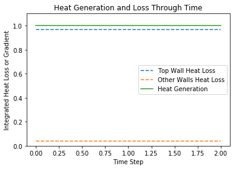

```python
if rank == 0:
    plt.clf()
    plt.plot(range(step),arrSurfHF[:step]/H,"--",label="Top Wall Heat Loss")
    plt.plot(range(step),arrOtherWallsHF[:step],"--",label="Other Walls Heat Loss")
    plt.plot(range(maxsteps),numpy.ones(maxsteps),label="Heat Generation")
    plt.ylim([0,max([1.1,max(arrSurfHF[:step]/H)])])
    plt.title("Heat Generation and Loss Through Time")
    plt.xlabel("Time Step")
    plt.ylabel("Integrated Heat Loss or Gradient")
    plt.legend(loc='best')
    if writefigures:
        plt.savefig("output/%s_heatlossandgeneration.pdf" %mname)
```

Plot the temperature and velocity vector fields and not the contrasts between isoviscous and stagnant lid convection.

Stagnant lid convection should be characterised by a thick thermal boundary layer, with negligible flow near the surface. Isoviscous convection should have a thin boundary layer and significant surface flow.

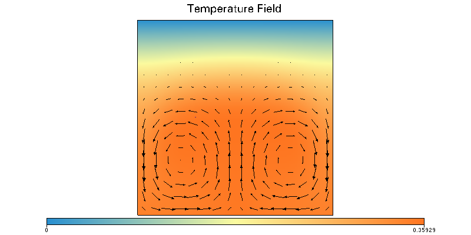

```python
figMaterial = glucifer.Figure( figsize=(800,400), title="Temperature Field" )
figMaterial.append( glucifer.objects.Surface(mesh,temperatureField ))
figMaterial.append( glucifer.objects.VectorArrows(mesh,1e3/Ra*velocityField))
figMaterial.append( glucifer.objects.Points(swarm=tracerTrackSwarm,colourBar=False,fn_size=5,colours="purple"))

if size == 1:
    figMaterial.show()

if writefigures:
    figMaterial.save_image("output/%s_TemperatureField" %mname)
```

Let's have a closer look at the surface velocity

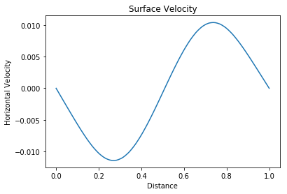

```python
n = 100
topWallX = numpy.linspace(mesh.minCoord[0],mesh.maxCoord[0],n)
topWallVelocity = numpy.zeros(n)

for i in range(n):
    topWallVelocity[i] = velocityField[0].evaluate_global((topWallX[i],mesh.maxCoord[1]))

if rank == 0:
    plt.clf()

    plt.plot(topWallX,topWallVelocity)

    plt.title("Surface Velocity")
    plt.ylabel("Horizontal Velocity")
    plt.xlabel("Distance")
    if writefigures:
        plt.savefig("output/%s_surface_velocity.pdf" %mname)
```

Calculate the vertical temperature gradient at the surface of the model, to see where the highest heat-loss is. We're running these models to steady-state, so the integrated surface heat-loss should not depend on the convective regime.

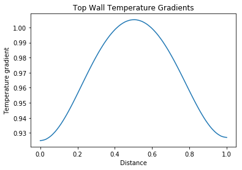

```python
n = 100
topWallX = numpy.linspace(mesh.minCoord[0],mesh.maxCoord[0],n)
topWalldTdZ = numpy.zeros(n)

for i in range(n):
    topWalldTdZ[i] = temperatureField.fn_gradient[1].evaluate_global((topWallX[i],mesh.maxCoord[1]))


if rank == 0:
    plt.clf()

    plt.plot(topWallX,abs(topWalldTdZ))

    plt.title("Top Wall Temperature Gradients")
    plt.ylabel("Temperature gradient")
    plt.xlabel("Distance")
    if writefigures:
        plt.savefig("output/%s_wall_gradients.pdf" %mname)
```

Let's calculate geotherms for three vertical cross-sections and compare to the predicted internal temperature for isoviscous convection.

Because stagnant lid has a thick boundary layer, its heat-loss is significantly less efficient than for isoviscous convection. Running to steady-state should result in extremely high internal temperatures, which you can compare to the predicted isoviscous convection temperature (dashed).

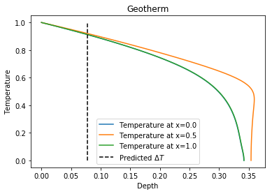

```python
if rank == 0:
    plt.clf()

n = 100
arrY = numpy.linspace(0,1,n)
for x in [0.,0.5,1.]:
    arrT = numpy.zeros(n)
    for i in range(n):
        arrT[i] = temperatureField.evaluate_global((x,arrY[i]))

    if rank == 0 :
        plt.plot(arrT,arrY,label="Temperature at x=%.1f" %x)

if rank ==0:
    plt.title("Geotherm")

    plt.plot(numpy.ones(n)*predTemp, numpy.linspace(0,1,n),"--",c="black",label="Predicted " + r"$\Delta T$")
    plt.ylabel("Temperature")
    plt.xlabel("Depth")
    plt.legend(loc='best')

    if writefigures:
        plt.savefig("output/%s_geotherm.pdf" %mname)
```

**Things to do:**

1. Switch writefigures to true, to save figures for comparison. Run in `isoviscous = True` mode, generating isoviscous convection plots. Then again for `isoviscous = False` mode for stagnant lid plots. Compare surface velocities and geotherms.
2. Make a slight change to the Rayleigh number and see how many time-steps it takes to reach a thermal steady-state, for stagnant lid and mobile lid. You might want to lower the resolution or run in parallel. What could this imply about cooling of the Earth during a stagnant lid regime? You might find "Energetics of mantle convection and the fate of fossil heat" by Korenaga (2003), interesting.
3. Lowering the maximum viscosity contrast or increasing the Rayleigh number should decrease the thickness of the stagnant lid, as described in `Stagnant Lid Convection on Venus' cited at the start. See if you can reproduce this!